# Multiple Linear Regression

## ASSIGNMENT 3: Multiple Linear Regression

## Model Assumptions and Completely Randomized Designs (CRD)

*Deadline: Dec. 9 , 2022, by 11:59 pm. Submit to Gradescope.ca*

© Thuntida Ngamkham 2022

**Problem 1**:

**From Assignment 1 Problem 1**, The amount of water used by the production facilities of a plant varies. Observations on water usage and other,possibility related,variables were collected for 249 months. The data is given in **water.csv file** The explanatory variables are

TEMP= average monthly temperature(degree celsius)

PROD=amount of production(10cubic)

DAYS=number of operationing day in the month

HOUR=number of hours shut down for maintenance

The response variable is USAGE=monthly water usage(gallons/minute)

```r
waterdata=read.csv("water.csv",header = TRUE )
head(water,5)
```

```r
model=lm(USAGE~PROD+TEMP+HOUR+DAYS, data=waterdata)
summary(model)
intermodel=lm(USAGE~(PROD+TEMP+HOUR)^2, data=waterdata)
summary(intermodel)
finalintermodel=lm(USAGE~PROD+TEMP+HOUR+PROD*TEMP+PROD*HOUR, data=waterdata)
summary(finalintermodel)
```

$$\begin{aligned}
\hat{USAGE}=\hat\beta_0PROD+\hat\beta_1TEMP+\hat\beta_2HOUR+\hat\beta_3PROD*TEMP+\hat\beta_4PROD*HOUR
\end{aligned}$$
Answer the following questions

1. Many researchers avoid the problems of multicollinearity by always omitting all but one of the ‘’redundant’’ variables from the model. By checking all pairwise combinations of predictors in scatterplots and using the VIF function, do you detect any high correlation (r>0.8) between predictors? Does there appear to be any problem with multicollinearity assumption?

```r
imcdiag(model, method="VIF")
cor(waterdata)
pairs(~PROD+TEMP+HOUR+DAYS, data=waterdata)
#Conclusion:I do not detect any high correlation (r>0.8) between predictors
#There does not appear to be any problem with multicollinearity assumption
#all vif <5 , not severe enough to warrant corrective measures.
```

2. Conduct a test for heteroscedasticity (non constant varaince) and plot a residual plot. Does there appear to be any problem with homoscedasticity assumption ?

Note: make sure you use the model provided above for your analysis.

$$
$$\begin{aligned}
H_0:&\mbox{ heteroscedasticity is not present }\\
H_a~:&\mbox{ heteroscedasticity is present} \\
\end{aligned}$$

```r
library(lmtest)

bptest(finalintermodel)
```

```r
plot(finalintermodel,which=3)
```

3. Provide a histogram for residuals, a normal Q-Q plot, and the Shapiro -Wilk test. Does there appear to be any problem with normality assumption?
   $$\begin{aligned}
   H_0:&\mbox{ the sample data are significantly normally
   distributed}\\
   H_a:&\mbox{ the sample data are not significantly normally
   distributed } \\
   \end{aligned}$$

```r
library(ggplot2)

#option 1 (histogram)
qplot(residuals(finalintermodel),
      geom="histogram",
      binwidth = 0.1,
      main = "Histogram of residuals",
      xlab = "residuals", color="red",
      fill=I("blue"))
#option 2 (histogram)
ggplot(data=waterdata, aes(residuals(finalintermodel))) +
  geom_histogram(breaks = seq(-1,1,by=0.1), col="red", fill="blue") +
  labs(title="Histogram for residuals") +
  labs(x="residuals", y="Count")

#normal QQ plot
ggplot(waterdata, aes(sample=finalintermodel$residuals)) +
  stat_qq() +
  stat_qq_line()

#optional histogram
par(mfrow=c(1,2))
hist(residuals(finalintermodel))
plot(finalintermodel, which=2) #a Normal plot

#Testing for Normality
shapiro.test(residuals(finalintermodel))
```

4. Plot the residuals vs predicted value $\hat{Y}$ plot, do you detect any patterns? Does there appear to be any problem with linearity assumption?

```r
plot(fitted(finalintermodel), residuals(finalintermodel),xlab="Fitted Values", ylab="Residuals")
abline(h=0,lty=1)
title("Residual vs Fitted")
```

5. Do you detect any outliers by using Cook’s distance measure (using cooks.distance()>1 ) and Residual vs Leverage plot?

```r
plot(finalintermodel,which=5)
waterdata[cooks.distance(finalintermodel)>0.5,] #have Cook statistics larger than 0.5
plot(finalintermodel,pch=18,col="red",which=c(4))
```

6. From part a-e, determine whether your model meets the assumptions of the analysis. If not, provide any suggestions to improve the model.

Box-Cox Transformations can help to improve the model.

**Problem 2:**

**From Assignment 2 Problem 4(c)**, variables CGDUR, MEM and SOCIALSU are consistently selected as the best predictors.

```r
KBI=read.csv("KBI.csv", header = TRUE)
model=lm(BURDEN~(CGDUR+ MEM +SOCIALSU) , data=KBI)
summary(model)
```

```r
interactionmodel=lm(BURDEN~(CGDUR+ MEM +SOCIALSU)^2 , data=KBI)
summary(interactionmodel)
```

Use the final model above to answer the following questions

1. Check normality, homoscedasticity, and linearity assumptions.

$$\begin{aligned}
H_0:&\mbox{ the sample data are significantly normally
distributed}\\
H_a:&\mbox{ the sample data are not significantly normally
distributed } \\
\end{aligned}$$

```r
#Testing for Normality
shapiro.test(residuals(model))
```

$$
$$\begin{aligned}
H_0:&\mbox{ heteroscedasticity is not present }\\
H_a~:&\mbox{ heteroscedasticity is present} \\
\end{aligned}$$

```r
bptest(model)
```

```r
plot(fitted(model), residuals(model),xlab="Fitted Values", ylab="Residuals")
abline(h=0,lty=1)
title("Residual vs Fitted")

ggplot(model, aes(x=.fitted, y=.resid)) +
  geom_point() +geom_smooth()+
  geom_hline(yintercept = 0)
```

2. Do you detect any outliers by using leverage values greater that $\frac{3p}{n}$? If yes, create a new dataset that removes these outliers.

```r
plot(model,which=5)
KBI[cooks.distance(model)>0.5,] #have Cook statistics larger than 0.5
plot(model,pch=18,col="red",which=c(4))
```

```r
lev=hatvalues(model)
p = length(coef(model))
n = nrow(KBI)
#outlier2p = lev[lev>(2*p/n)]
outlier3p = lev[lev>(3*p/n)]
#print("h_I>2p/n, outliers are")
#print(outlier2p)
print("h_I>3p/n, outliers are")
print(outlier3p)
plot(rownames(KBI),lev, main = "Leverage IN KBI Dataset", xlab="observation",
    ylab = "Leverage Value")
#abline(h = 2 *p/n, lty = 1)
abline(h = 3 *p/n, lty = 1)
KBI1 = KBI[lev <= ( 3 *p/n), ]
```

3. Fit the model

$$\widehat{BURDEN}= \hat{\beta_0} + \hat{\beta_1}MEM +
\hat{\beta_2}SOCIALSU + \hat{\beta_3}CGDUR$$

again using the new dataset created in part (b). Compare the results with the model the final model from **From Assignment 2 Problem 4(c)** . Do you notice any difference in the results of this model using two different data sets.

```r
model1=lm(BURDEN~(CGDUR+ MEM +SOCIALSU) , data=KBI1)
summary(model1)
model=lm(BURDEN~(CGDUR+ MEM +SOCIALSU) , data=KBI)
summary(model)

#Interpretation and conclusion: I Do notice difference in the results of this model using two different data sets.
#the model using the new dataset has higher Adjusted R-squared which is 0.43, and lower RMSE which is 15.19 compare to the old one.
```

[output not shown]

**Problem 3:**

The average butterfat content of milk from dairy cows was recorded for each of five breeds of cattle. Random samples of ten mature (older than 4 years) and ten 2-year olds were taken.

The data are saved in the file named **butterfat.csv**

1. Plot box-plots using the R command boxplot( ) or ggplot( ) as in DATA 602 for the butterfat against breed, and also against age. Compare the variability: interquartile range ($Q_3-Q_1$) among breed’s levels and among age’s levels

```r
options(scipen = 999)
q3=read.csv("butterfat.csv", header = TRUE)
head(q3)
```

|  | Butterfat | Breed | Age |
| --- | --- | --- | --- |
| 1 | 3.74 | Ayrshire | Mature |
| 2 | 4.01 | Ayrshire | 2year |
| 3 | 3.77 | Ayrshire | Mature |
| 4 | 3.78 | Ayrshire | 2year |
| 5 | 4.10 | Ayrshire | Mature |
| 6 | 4.06 | Ayrshire | 2year |

```r
tail(q3)
```

|  | Butterfat | Breed | Age |
| --- | --- | --- | --- |
| 95 | 5.18 | Jersey | Mature |
| 96 | 4.22 | Jersey | 2year |
| 97 | 5.98 | Jersey | Mature |
| 98 | 4.85 | Jersey | 2year |
| 99 | 6.55 | Jersey | Mature |
| 100 | 5.72 | Jersey | 2year |

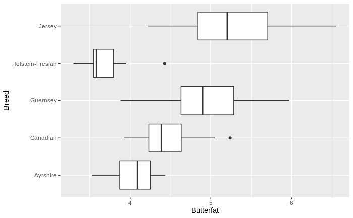

```r
require(reshape2)
ggplot(data = q3, aes(x=Butterfat, y=Breed)) + geom_boxplot(aes(fill=Butterfat))
```

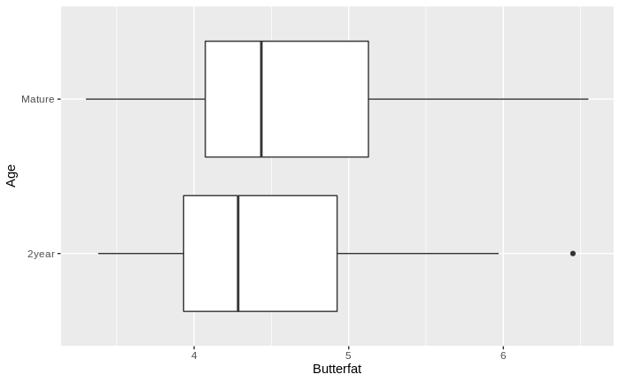

```r
ggplot(data = q3, aes(x=Butterfat, y=Age)) + geom_boxplot(aes(fill=Butterfat))
```

2. Fit a linear model using Age and Breed as independent variables. Would you keep Age in your model?

```r
model1=lm(Butterfat~ factor(Breed) + factor(Age) , data=q3)
summary(model1)
```

```
Call:
lm(formula = Butterfat ~ factor(Breed) + factor(Age), data = q3)

Residuals:
    Min      1Q  Median      3Q     Max
-1.0202 -0.2373 -0.0640  0.2617  1.2098

Coefficients:
                              Estimate Std. Error t value             Pr(>|t|)
(Intercept)                    4.00770    0.10135  39.541 < 0.0000000000000002 ***
factor(Breed)Canadian          0.37850    0.13085   2.893              0.00475 **
factor(Breed)Guernsey          0.89000    0.13085   6.802  0.00000000094806446 ***
factor(Breed)Holstein-Fresian -0.39050    0.13085  -2.984              0.00362 **
factor(Breed)Jersey            1.23250    0.13085   9.419  0.00000000000000316 ***
factor(Age)Mature              0.10460    0.08276   1.264              0.20937
---
Signif. codes:  0 ‘***’ 0.001 ‘**’ 0.01 ‘*’ 0.05 ‘.’ 0.1 ‘ ’ 1

Residual standard error: 0.4138 on 94 degrees of freedom
Multiple R-squared:  0.6825,    Adjusted R-squared:  0.6656
F-statistic: 40.41 on 5 and 94 DF,  p-value: < 0.00000000000000022
```

```r
model1=lm(Butterfat~ factor(Breed) , data=q3)
summary(model1)
```

```
Call:
lm(formula = Butterfat ~ factor(Breed), data = q3)

Residuals:
     Min       1Q   Median       3Q      Max
-1.07250 -0.27213 -0.05125  0.22363  1.25750

Coefficients:
                              Estimate Std. Error t value             Pr(>|t|)
(Intercept)                    4.06000    0.09281  43.743 < 0.0000000000000002 ***
factor(Breed)Canadian          0.37850    0.13126   2.884              0.00486 **
factor(Breed)Guernsey          0.89000    0.13126   6.780  0.00000000100941928 ***
factor(Breed)Holstein-Fresian -0.39050    0.13126  -2.975              0.00371 **
factor(Breed)Jersey            1.23250    0.13126   9.390  0.00000000000000333 ***
---
Signif. codes:  0 ‘***’ 0.001 ‘**’ 0.01 ‘*’ 0.05 ‘.’ 0.1 ‘ ’ 1

Residual standard error: 0.4151 on 95 degrees of freedom
Multiple R-squared:  0.6771,    Adjusted R-squared:  0.6635
F-statistic:  49.8 on 4 and 95 DF,  p-value: < 0.00000000000000022
```

```r
#I would not keep Age in my model because it is not significant.
```

From the outputs above, the best-fit model is

$$\begin{aligned}
\hat{Butterfat}=4.06000+0.37850Breed_{1i}+0.89000Breed_{2i}-0.39050Breed_{2i}+1.23250Breed_{3i}
\end{aligned}$$

3. Perform a diagnostics (normality and constant variance assumptions, Normal Q-Q plot) analysis for your model fitted in part (b). What is your conclusion?
   $$\begin{aligned}
   H_0:&\mbox{ the sample data are significantly normally
   distributed}\\
   H_a:&\mbox{ the sample data are not significantly normally
   distributed } \\
   \end{aligned}$$

```r
#Testing for Normality
shapiro.test(residuals(model1))
```

```
    Shapiro-Wilk normality test

data:  residuals(model1)
W = 0.96805, p-value = 0.01571
```

$$
$$\begin{aligned}
H_0:&\mbox{ heteroscedasticity is not present }\\
H_a~:&\mbox{ heteroscedasticity is present} \\
\end{aligned}$$

```r
bptest(model1)
```

```
    studentized Breusch-Pagan test

data:  model1
BP = 13.389, df = 4, p-value = 0.009525
```

```r
#normal QQ plot
ggplot(q3, aes(sample=model1$residuals)) +
  stat_qq() +
  stat_qq_line()

#optional histogram
par(mfrow=c(1,2))
```

[output not shown]

conclusion: both assumptions do not meet.

4. Fit an appropriate linear regression model by identifying a suitable transformation of your response variable [Box-Cox Transformation]. Compare the results with the model fitted in part

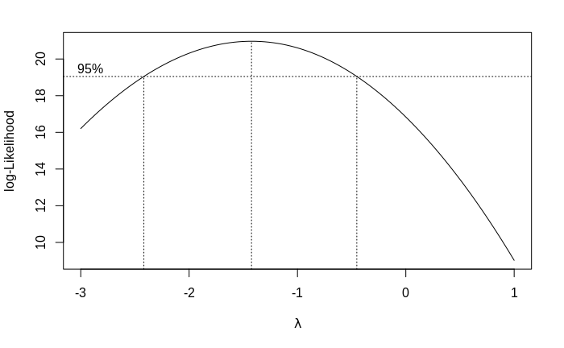

```r
library(MASS) #for the boxcox()function
bc=boxcox(model1,lambda=seq(-3,1))
```

```r
#extract best lambda
bestlambda=bc$x[which(bc$y==max(bc$y))]
bestlambda
```

```
[1] -1.424242
```

```r
model1=lm(Butterfat~ factor(Breed) , data=q3)
summary(model1)
```

```
Call:
lm(formula = Butterfat ~ factor(Breed), data = q3)

Residuals:
     Min       1Q   Median       3Q      Max
-1.07250 -0.27213 -0.05125  0.22363  1.25750

Coefficients:
                              Estimate Std. Error t value             Pr(>|t|)
(Intercept)                    4.06000    0.09281  43.743 < 0.0000000000000002 ***
factor(Breed)Canadian          0.37850    0.13126   2.884              0.00486 **
factor(Breed)Guernsey          0.89000    0.13126   6.780  0.00000000100941928 ***
factor(Breed)Holstein-Fresian -0.39050    0.13126  -2.975              0.00371 **
factor(Breed)Jersey            1.23250    0.13126   9.390  0.00000000000000333 ***
---
Signif. codes:  0 ‘***’ 0.001 ‘**’ 0.01 ‘*’ 0.05 ‘.’ 0.1 ‘ ’ 1

Residual standard error: 0.4151 on 95 degrees of freedom
Multiple R-squared:  0.6771,    Adjusted R-squared:  0.6635
F-statistic:  49.8 on 4 and 95 DF,  p-value: < 0.00000000000000022
```

```r
bcmodel=lm((((Butterfat^-1.424242)-1)/-1.424242) ~factor(Breed), data = q3)
summary(bcmodel)
```

```
Call:
lm(formula = (((Butterfat^-1.424242) - 1)/-1.424242) ~ factor(Breed),
    data = q3)

Residuals:
       Min         1Q     Median         3Q        Max
-0.0286891 -0.0060992  0.0000438  0.0073002  0.0267700

Coefficients:
                               Estimate Std. Error t value             Pr(>|t|)
(Intercept)                    0.606021   0.002235 271.165 < 0.0000000000000002 ***
factor(Breed)Canadian          0.011144   0.003161   3.526             0.000652 ***
factor(Breed)Guernsey          0.022989   0.003161   7.274  0.00000000009892312 ***
factor(Breed)Holstein-Fresian -0.014954   0.003161  -4.732  0.00000775058571188 ***
factor(Breed)Jersey            0.029329   0.003161   9.280  0.00000000000000573 ***
---
Signif. codes:  0 ‘***’ 0.001 ‘**’ 0.01 ‘*’ 0.05 ‘.’ 0.1 ‘ ’ 1

Residual standard error: 0.009995 on 95 degrees of freedom
Multiple R-squared:  0.7274,    Adjusted R-squared:  0.7159
F-statistic: 63.36 on 4 and 95 DF,  p-value: < 0.00000000000000022
```

Comparison of models: The new model has a higher Adjusted R-squared which is 0.7159 and a much lower RMSE of 0.009995.

5. Perform a diagnostics analysis for the model fitted in part (d)
   $$\begin{aligned}
   H_0:&\mbox{ the sample data are significantly normally
   distributed}\\
   H_a:&\mbox{ the sample data are not significantly normally
   distributed } \\
   \end{aligned}$$

```r
#Testing for Normality
shapiro.test(residuals(bcmodel))
```

```
    Shapiro-Wilk normality test

data:  residuals(bcmodel)
W = 0.99449, p-value = 0.9596
```

Shapiro-Wilk normality test shows that the residuals are normally distributed as the p-value=0.9596 > 0.05. we fail to reject the null hypothesis, normality assumption does meet.

$$
$$\begin{aligned}
H_0:&\mbox{ heteroscedasticity is not present }\\
H_a~:&\mbox{ heteroscedasticity is present} \\
\end{aligned}$$

```r
bptest(bcmodel)
```

```
    studentized Breusch-Pagan test

data:  bcmodel
BP = 0.58064, df = 4, p-value = 0.9652
```

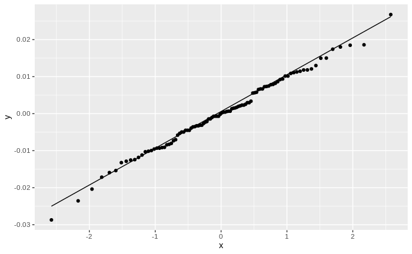

```r
#normal QQ plot
ggplot(q3, aes(sample=bcmodel$residuals)) +
  stat_qq() +
  stat_qq_line()

#optional histogram
par(mfrow=c(1,2))
```